# chapter6

khorloo batpurev

2023-12-11

# Week 6 - Longitudinal analysis

### *Part 1 - Data wrangling and preparation*

#### **Task 1 - Load in the data, explore structure**

```r
bprs<-read.delim2("https://raw.githubusercontent.com/KimmoVehkalahti/MABS/master/Examples/data/BPRS.txt",header = TRUE, sep = " ", dec = ",")

rats<-read.delim2("https://raw.githubusercontent.com/KimmoVehkalahti/MABS/master/Examples/data/rats.txt",header = TRUE, sep = "\t", dec = ",")
```

```r
names(bprs)
```

```
##  [1] "treatment" "subject"   "week0"     "week1"     "week2"     "week3"
##  [7] "week4"     "week5"     "week6"     "week7"     "week8"
```

```r
summary(bprs)
```

```
##    treatment      subject          week0           week1           week2
##  Min.   :1.0   Min.   : 1.00   Min.   :24.00   Min.   :23.00   Min.   :26.0
##  1st Qu.:1.0   1st Qu.: 5.75   1st Qu.:38.00   1st Qu.:35.00   1st Qu.:32.0
##  Median :1.5   Median :10.50   Median :46.00   Median :41.00   Median :38.0
##  Mean   :1.5   Mean   :10.50   Mean   :48.00   Mean   :46.33   Mean   :41.7
##  3rd Qu.:2.0   3rd Qu.:15.25   3rd Qu.:58.25   3rd Qu.:54.25   3rd Qu.:49.0
##  Max.   :2.0   Max.   :20.00   Max.   :78.00   Max.   :95.00   Max.   :75.0
##      week3           week4           week5           week6           week7
##  Min.   :24.00   Min.   :20.00   Min.   :20.00   Min.   :19.00   Min.   :18.0
##  1st Qu.:29.75   1st Qu.:28.00   1st Qu.:26.00   1st Qu.:22.75   1st Qu.:23.0
##  Median :36.50   Median :34.50   Median :30.50   Median :28.50   Median :30.0
##  Mean   :39.15   Mean   :36.35   Mean   :32.55   Mean   :31.23   Mean   :32.2
##  3rd Qu.:44.50   3rd Qu.:43.00   3rd Qu.:38.00   3rd Qu.:37.00   3rd Qu.:38.0
##  Max.   :76.00   Max.   :66.00   Max.   :64.00   Max.   :64.00   Max.   :62.0
##      week8
##  Min.   :20.00
##  1st Qu.:22.75
##  Median :28.00
##  Mean   :31.43
##  3rd Qu.:35.25
##  Max.   :75.00
```

This is a repeated measures dataset with 40 rows and 11 columns. There are 2 types of treatments (1 and 2) and 20 participants in each treatment. The treatments have been repeated over a period of 8 weeks on each participant, with an initial measurement at week0.

```r
names(rats)
```

```
##  [1] "ID"    "Group" "WD1"   "WD8"   "WD15"  "WD22"  "WD29"  "WD36"  "WD43"
## [10] "WD44"  "WD50"  "WD57"  "WD64"
```

```r
summary(rats)
```

```
##        ID            Group           WD1             WD8             WD15
##  Min.   : 1.00   Min.   :1.00   Min.   :225.0   Min.   :230.0   Min.   :230.0
##  1st Qu.: 4.75   1st Qu.:1.00   1st Qu.:252.5   1st Qu.:255.0   1st Qu.:255.0
##  Median : 8.50   Median :1.50   Median :340.0   Median :345.0   Median :347.5
##  Mean   : 8.50   Mean   :1.75   Mean   :365.9   Mean   :369.1   Mean   :372.5
##  3rd Qu.:12.25   3rd Qu.:2.25   3rd Qu.:480.0   3rd Qu.:476.2   3rd Qu.:486.2
##  Max.   :16.00   Max.   :3.00   Max.   :555.0   Max.   :560.0   Max.   :565.0
##       WD22            WD29            WD36            WD43
##  Min.   :232.0   Min.   :240.0   Min.   :240.0   Min.   :243.0
##  1st Qu.:267.2   1st Qu.:268.8   1st Qu.:267.2   1st Qu.:269.2
##  Median :351.5   Median :356.5   Median :360.0   Median :360.0
##  Mean   :379.2   Mean   :383.9   Mean   :387.0   Mean   :386.0
##  3rd Qu.:492.5   3rd Qu.:497.8   3rd Qu.:504.2   3rd Qu.:501.0
##  Max.   :580.0   Max.   :590.0   Max.   :597.0   Max.   :595.0
##       WD44            WD50            WD57            WD64
##  Min.   :244.0   Min.   :238.0   Min.   :247.0   Min.   :245.0
##  1st Qu.:270.0   1st Qu.:273.8   1st Qu.:273.8   1st Qu.:278.0
##  Median :362.0   Median :370.0   Median :373.5   Median :378.0
##  Mean   :388.3   Mean   :394.6   Mean   :398.6   Mean   :404.1
##  3rd Qu.:510.5   3rd Qu.:516.0   3rd Qu.:524.5   3rd Qu.:530.8
##  Max.   :595.0   Max.   :612.0   Max.   :618.0   Max.   :628.0
```

#### **Task 2 - Factorise variables**

```r
#The two categorical variables in bprs dataset are the Treatment type and the Subject, the rest are continuous.
bprs$treatment<-as.factor(bprs$treatment)
bprs$subject<-as.factor(bprs$subject)

#In rats data its the ID and Group variables that are categorical, and the rest are continous.
rats$ID<-as.factor(rats$ID)
rats$Group<-as.factor(rats$Group)
```

#### **Task 3 - Reshape the dataframes**

```r
bprslong<-pivot_longer(bprs,
                       cols = -c(treatment, subject),
                       names_to = "weeks",
                       values_to="values")%>%
  mutate(weeks = as.integer(substr(weeks, 5, 5)))%>%arrange(weeks)
head(bprslong)
```

```
## # A tibble: 6 × 4
##   treatment subject weeks values
##   <fct>     <fct>   <int>  <int>
## 1 1         1           0     42
## 2 1         2           0     58
## 3 1         3           0     54
## 4 1         4           0     55
## 5 1         5           0     72
## 6 1         6           0     48
```

```r
ratslong<-pivot_longer(rats,
                       cols = -c(ID, Group),
                       names_to = "time",
                       values_to="values")%>%arrange(time)
head(ratslong)
```

```
## # A tibble: 6 × 4
##   ID    Group time  values
##   <fct> <fct> <chr>  <int>
## 1 1     1     WD1      240
## 2 2     1     WD1      225
## 3 3     1     WD1      245
## 4 4     1     WD1      260
## 5 5     1     WD1      255
## 6 6     1     WD1      260
```

#### **Task 4 - Understand the long format**

```r
#View(bprslong)
summary(bprslong)
```

```
##  treatment    subject        weeks       values
##  1:180     1      : 18   Min.   :0   Min.   :18.00
##  2:180     2      : 18   1st Qu.:2   1st Qu.:27.00
##            3      : 18   Median :4   Median :35.00
##            4      : 18   Mean   :4   Mean   :37.66
##            5      : 18   3rd Qu.:6   3rd Qu.:43.00
##            6      : 18   Max.   :8   Max.   :95.00
##            (Other):252
```

```r
#View(ratslong)
summary(ratslong)
```

```
##        ID      Group      time               values
##  1      : 11   1:88   Length:176         Min.   :225.0
##  2      : 11   2:44   Class :character   1st Qu.:267.0
##  3      : 11   3:44   Mode  :character   Median :344.5
##  4      : 11                             Mean   :384.5
##  5      : 11                             3rd Qu.:511.2
##  6      : 11                             Max.   :628.0
##  (Other):110
```

The long format allows us to structure data in a way that separates the repeated measures or the “nestedness” of the data from the measurements which are always continuous and numerical. The long format is necessary for linear mixed models that require all the predictor variables under one variable name (syntax wise as well as model interpretation wise), separated from the identity of variables that tells us about the hierarchy in the data (nestedness/repeated measures).

The bprs long format has 360 rows and 4 variables, compared to the 40 rows and 11 variables in wide format. Each treatment is comprised of 180 values, the measurement for each subject is repeated 9 times (including week0) under each treatment. These are 40 men (subject 1 - 20 in each treatment) who have gone under two types of psychiatric treatments (1 and 2) over 8 weeks. Caution have to be taken, in that the way the subject ID has been coded in this dataset (1-20 rather than 1-40), it could be interpreted that there are only 20 men going under 2 types of treatments over 8 weeks period. But that is not the case! The values for the subjects under both treatment ranges between 18 and 95. This is a balanced dataset,in that has equal number of values for each treatment and subject.

Similarly, the rats long format has 176 observations and 4 variables vs 16 obs and 13 variables in the wide format. Group one has 88 observations compared to group 2 and 3, so this is not a balanced dataset. Weight values of rats under treatments range between 225 and 628.

### Part 2 - Meat and repeat 1

#### **Task 1 - Data exploration and ANOVA**

##### Overview plots

```r
#Summary visualisation on BPRS data
bprslong$weeks<-as.factor(bprslong$weeks)
bprs_sst <- bprslong %>%
  group_by(treatment, weeks) %>%
  summarise( mean = mean(values),
             sd = sd(values),
             n = n(),
             se = sd / sqrt(n)) %>%
  ungroup()
```

```
## `geom_line()`: Each group consists of only one observation.
## ℹ Do you need to adjust the group aesthetic?
```

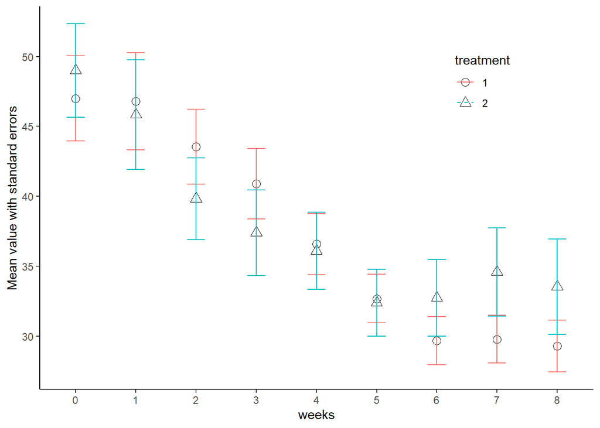

```r
gg1<-ggplot(bprs_sst, aes(x = weeks, y = mean, linetype = treatment, shape = treatment)) +
  geom_line() + theme_classic()+
  scale_linetype_manual(values = c(1,2)) +
  geom_point(size=3) +
  scale_shape_manual(values = c(1,2)) +
  geom_errorbar(aes(ymin=mean-se, ymax=mean+se, linetype="1",group=treatment,colour=treatment), width=0.3) +
  theme(legend.position = c(0.8,0.8))+
  ylab("Mean value with standard errors")
gg1
```

```r
#Summary visualisation on RATS data
rats_sst <- ratslong %>%
  group_by(Group, time) %>%
  summarise( mean = mean(values),
             sd = sd(values),
             n = n(),
             se = sd / sqrt(n))%>%ungroup()
```

```
## `geom_line()`: Each group consists of only one observation.
## ℹ Do you need to adjust the group aesthetic?
```

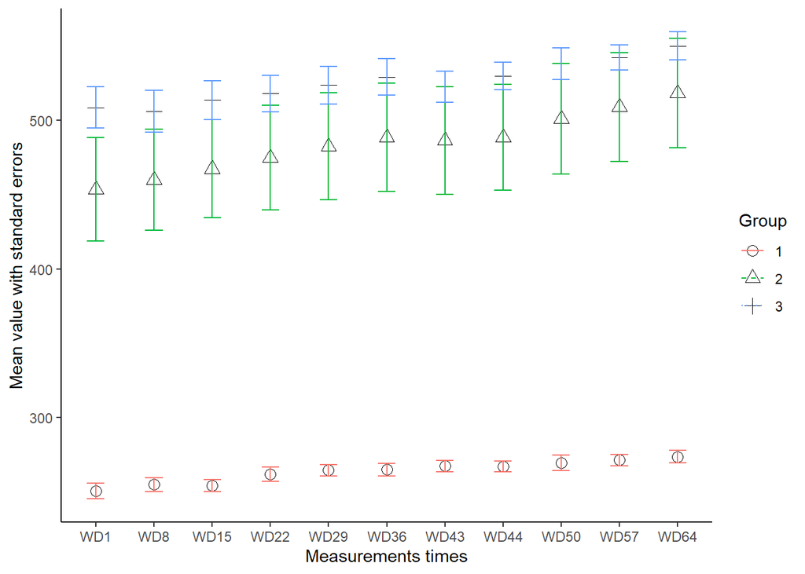

```r
#Ordering like this is necessary, otherwise the second time variable WD8 comes at last (ggplot thinks 8>1)
level_order<- c("WD1","WD8", "WD15", "WD22", "WD29", "WD36", "WD43", "WD44","WD50","WD57","WD64")

gg2<-ggplot(rats_sst, aes(x = factor(time,level=level_order), y = mean, linetype = Group, shape = Group)) +
  geom_line() + theme_classic()+
  scale_linetype_manual(values = c(1,2,3)) +
  geom_point(size=3) +
  scale_shape_manual(values = c(1,2,3)) +
  geom_errorbar(aes(ymin=mean-se, ymax=mean+se, linetype="1",group=Group,colour=Group), width=0.3) +
  ylab("Mean value with standard errors")+
  xlab("Measurements times")
gg2
```

This is a much more linear relationship where the treatment effect inreases the animals’ weight over time. There is a group level effect, with Group 1 having the lowest mean (<300grams) and Group 2 and 3 more comparable means around 450-550 grams.

##### Outliear plots

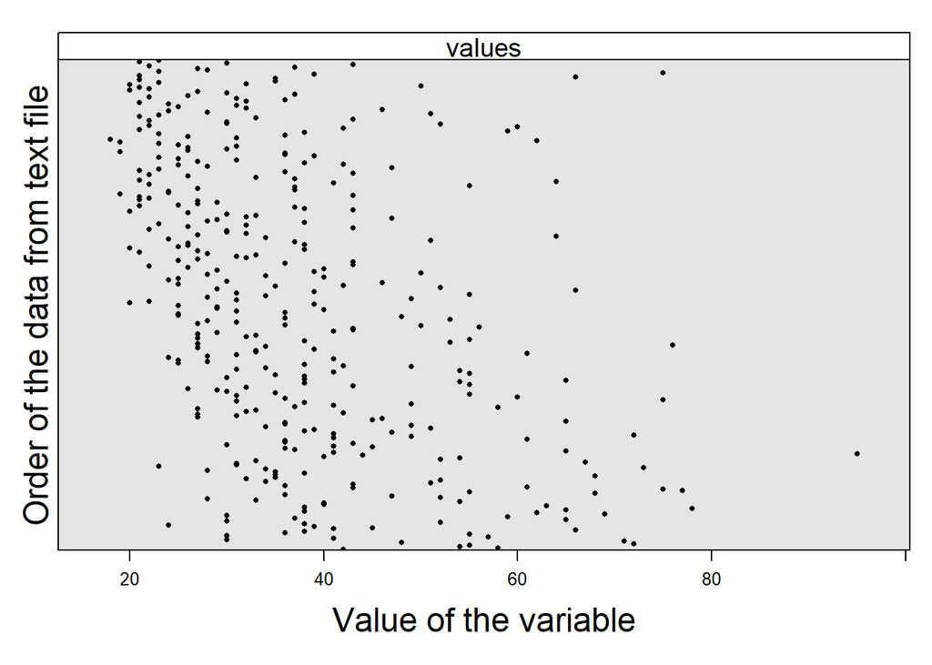

```r
#Cleveland plot function = this is my preferred way to see outliers.
library(latticeExtra)
Mydotplot =
  function(DataSelected){
P <- lattice::dotplot(as.matrix(as.matrix(DataSelected)),
          groups=FALSE,
          strip = strip.custom(bg = 'white',
                               par.strip.text = list(cex = 1.2)),
          scales = list(x = list(relation = "free", draw = TRUE),
                        y = list(relation = "free", draw = FALSE)),
          col=1, cex  = 0.5, pch = 16,
          xlab = list(label = "Value of the variable", cex = 1.5),
          ylab = list(label = "Order of the data from text file", cex = 1.5))

print(P)
  }

#Select the variables that you want to see if there is an outlier. You can expand the Myvar string which is useful when there are multiple variables. Otherwise the syntax in [] gets a little unruly.
Myvar <- c("values")
Mydotplot(bprslong[,Myvar])
```

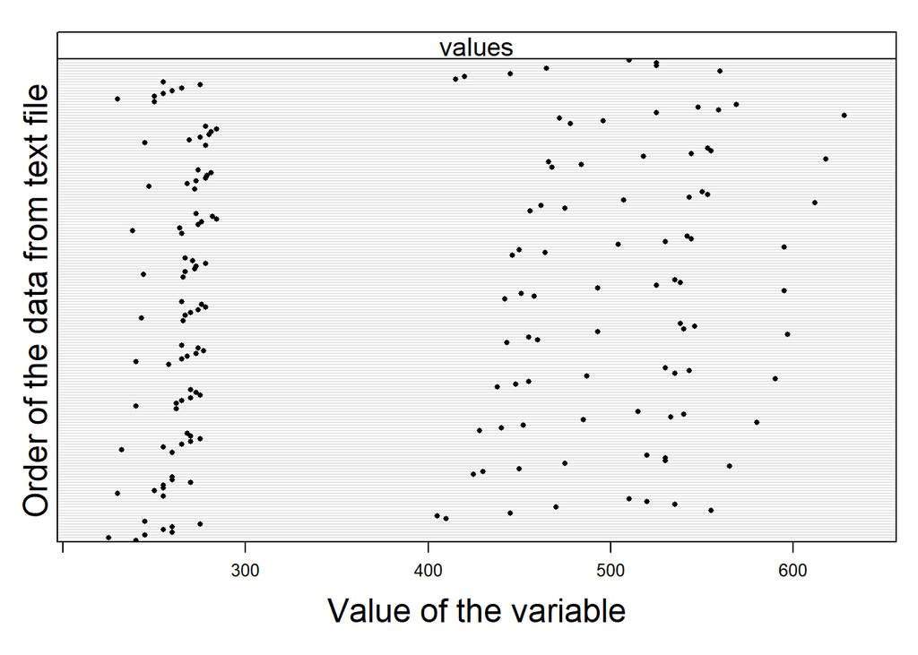

```r
Mydotplot(ratslong[,Myvar])
```

There is potentially one outliear in BPRS data (~value of around 95)! It relates to subject 11 under treatment 2 in week 1. It might be worth checking the overview without this point to see if the general trend changes.

There doesn’t seem to be an obvious outlier in RATS data.

```r
bprs_sst <- bprslong %>%
  filter(values<94)%>%
  group_by(treatment, weeks) %>%
  summarise( mean = mean(values),
             sd = sd(values),
             n = n(),
             se = sd / sqrt(n)) %>%
  ungroup()
```

```
## `geom_line()`: Each group consists of only one observation.
## ℹ Do you need to adjust the group aesthetic?
```

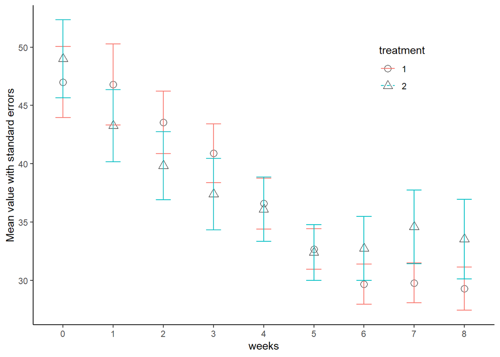

```r
gg3<-ggplot(bprs_sst, aes(x = weeks, y = mean, linetype = treatment, shape = treatment)) +
  geom_line() + theme_classic()+
  scale_linetype_manual(values = c(1,2)) +
  geom_point(size=3) +
  scale_shape_manual(values = c(1,2)) +
  geom_errorbar(aes(ymin=mean-se, ymax=mean+se, linetype="1",group=treatment,colour=treatment), width=0.3) +
  theme(legend.position = c(0.8,0.8))+
  ylab("Mean value with standard errors")
gg3
```

- *non-linear effect over time*
- *convergence and then divergence around week 5*
- *possibly interactive relationship between measurement time and means*

Worth noting that it is a bit of a subjective call to identify outlier, some may choose a value that is much lower than the single point that I identified. In the course material makes this call around 70, which could be a little bit restrictive. Perhaps a more elementary plot with individuals as lines will inform us a little further about this.

```r
bprslong_std<- bprslong %>%
  group_by(weeks) %>%
  mutate( stdvals = (values - mean(values))/sd(values) ) %>%
  ungroup()
glimpse(bprslong_std)
```

```
## Rows: 360
## Columns: 5
## $ treatment <fct> 1, 1, 1, 1, 1, 1, 1, 1, 1, 1, 1, 1, 1, 1, 1, 1, 1, 1, 1, 1, …
## $ subject   <fct> 1, 2, 3, 4, 5, 6, 7, 8, 9, 10, 11, 12, 13, 14, 15, 16, 17, 1…
## $ weeks     <fct> 0, 0, 0, 0, 0, 0, 0, 0, 0, 0, 0, 0, 0, 0, 0, 0, 0, 0, 0, 0, …
## $ values    <int> 42, 58, 54, 55, 72, 48, 71, 30, 41, 57, 30, 55, 36, 38, 66, …
## $ stdvals   <dbl> -0.4245908, 0.7076513, 0.4245908, 0.4953559, 1.6983632, 0.00…
```

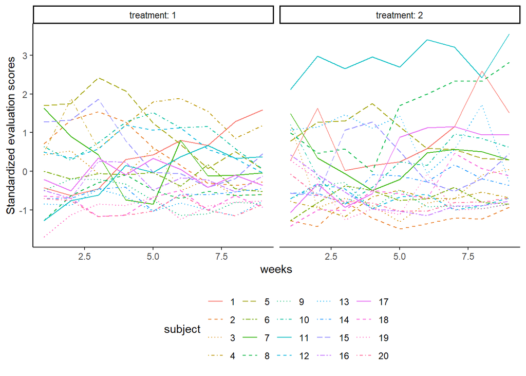

```r
bprslong_std$weeks<-as.integer(bprslong_std$weeks)
gg4<-ggplot(bprslong_std, aes(x = weeks, y = stdvals, linetype =subject,colour=subject))+
  geom_line() +
  scale_linetype_manual(values = rep(1:10, times=4))+
  facet_grid(. ~ treatment,labeller = label_both)+
  theme_classic() + theme(legend.position = "bottom")+
  theme(panel.grid.minor.y = element_blank())+
  scale_y_continuous(name = "Standardized evaluation scores")
gg4
```

As suspected, person 11 under treatment 20 is much higher distress level than the rest of the participants. I would say that unless there is suspected study communication failure with this person, there is no grounds to remove the individual assessment score that we discussed earlier as an outlier.

```r
ratslong_std<- ratslong %>%
  group_by(time) %>%
  mutate( stdvals = (values - mean(values))/sd(values) ) %>%
    mutate(time = as.integer(substr(time, 3, 3)))%>%
  ungroup()
glimpse(ratslong_std)
```

```
## Rows: 176
## Columns: 5
## $ ID      <fct> 1, 2, 3, 4, 5, 6, 7, 8, 9, 10, 11, 12, 13, 14, 15, 16, 1, 2, 3…
## $ Group   <fct> 1, 1, 1, 1, 1, 1, 1, 1, 2, 2, 2, 2, 3, 3, 3, 3, 1, 1, 1, 1, 1,…
## $ time    <int> 1, 1, 1, 1, 1, 1, 1, 1, 1, 1, 1, 1, 1, 1, 1, 1, 1, 1, 1, 1, 1,…
## $ values  <int> 240, 225, 245, 260, 255, 260, 275, 245, 410, 405, 445, 555, 47…
## $ stdvals <dbl> -1.0011429, -1.1203857, -0.9613953, -0.8421525, -0.8819001, -0…
```

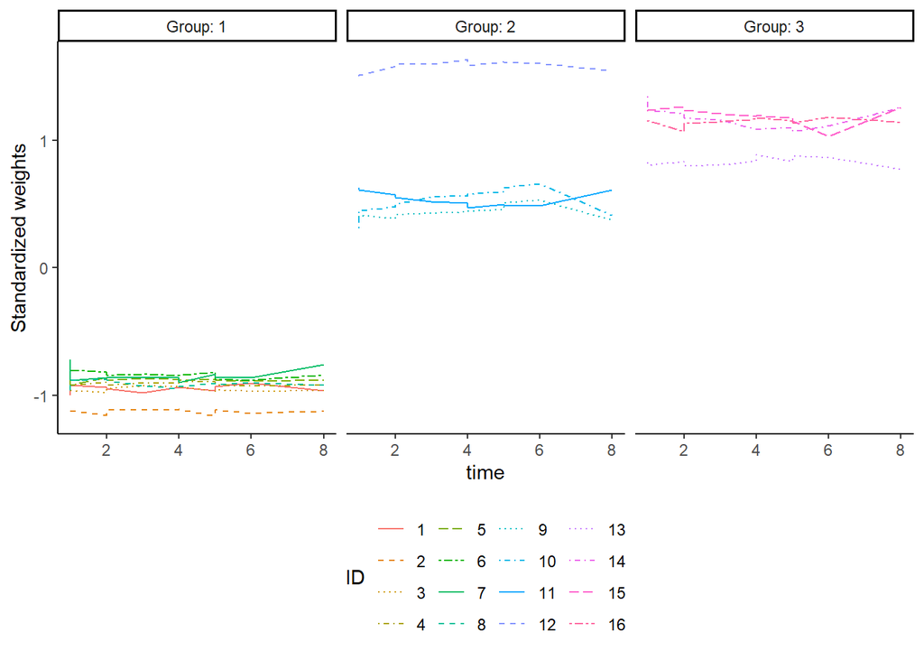

```r
gg4<-ggplot(ratslong_std, aes(x = time, y = stdvals, linetype =ID,colour=ID))+
  geom_line() +
  scale_linetype_manual(values = rep(1:10, times=4))+
  facet_grid(. ~ Group,labeller = label_both)+
  theme_classic() + theme(legend.position = "bottom")+
  theme(panel.grid.minor.y = element_blank())+
  scale_y_continuous(name = "Standardized weights")
gg4
```

There could be some individuals that are unusual. Boxplot maybe useful!

```r
ratslong_sum<- ratslong%>%
  group_by(Group, ID) %>%
  summarise( mean=mean(values) ) %>%
  ungroup()
str(ratslong_sum)
```

```
## tibble [16 × 3] (S3: tbl_df/tbl/data.frame)
##  $ Group: Factor w/ 3 levels "1","2","3": 1 1 1 1 1 1 1 1 2 2 ...
##  $ ID   : Factor w/ 16 levels "1","2","3","4",..: 1 2 3 4 5 6 7 8 9 10 ...
##  $ mean : num [1:16] 261 238 260 267 269 ...
```

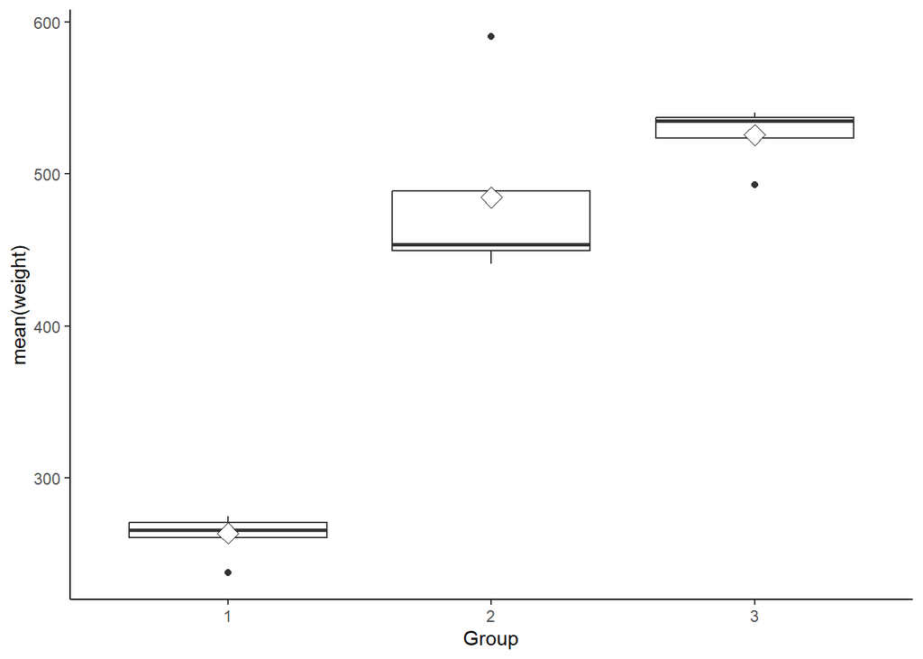

```r
ggplot(ratslong_sum, aes(x = Group, y = mean)) +
  geom_boxplot() + theme_classic()+
  stat_summary(fun = "mean", geom = "point", shape=23, size=4, fill = "white") +
  scale_y_continuous(name = "mean(weight)")
```

Hmmm, there is an outliear in each of the 3 groups…how inconvenient! This is a bit more complex than filter(value <|> x) type filter because there is one in each group. And the values have to be assessed in a slightly more nuanced way.

##### Remove outliers

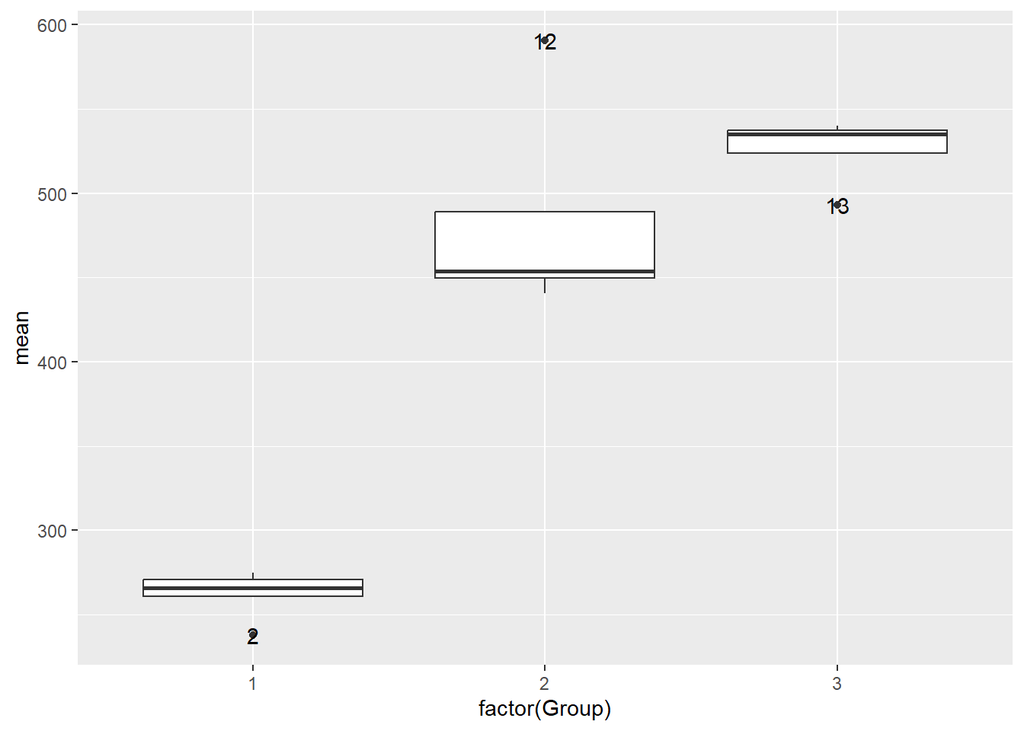

```r
#This is a function that would be used to calculate the outlier in each group
is_outlier <- function(x) {
  return(x < quantile(x, 0.25) - 1.5 * IQR(x) | x > quantile(x, 0.75) + 1.5 * IQR(x))
}

#We do some arithmetics on the summary dataframe
ratss<- ratslong_sum %>%tibble::rownames_to_column(var="outlier") %>% group_by(Group) %>% mutate(is_outlier=ifelse(is_outlier(mean), mean, as.numeric(NA)))
ratss$outlier[which(is.na(ratss$is_outlier))] <- as.numeric(NA)

ggplot(ratss, aes(y=mean, x=factor(Group))) + geom_boxplot() + geom_text(aes(label=outlier),na.rm=TRUE,nudge_y=0.05)
```

As you can see, rat 2 in Group 1, Rat 12 in Group 2 and Rat 13 in Group 3 are outliers in each group. Now we know this, we can remove them from the dataset.

```r
head(ratss)
```

```
## # A tibble: 6 × 5
## # Groups:   Group [1]
##   outlier Group ID     mean is_outlier
##   <chr>   <fct> <fct> <dbl>      <dbl>
## 1 <NA>    1     1      261.        NA
## 2 2       1     2      238.       238.
## 3 <NA>    1     3      260.        NA
## 4 <NA>    1     4      267.        NA
## 5 <NA>    1     5      269.        NA
## 6 <NA>    1     6      275.        NA
```

```r
#This removes the outliers from the database.
rats1<-ratss %>% filter(is.na(is_outlier))
```

##### *T-test ANOVA*

T-tests are famously 2 sided, so that means we can only compare 2 groups at a time. We will have to do this by a pair at a time.

```r
rats_1_2<-rats1%>%filter(Group==1|Group==2)
rats_2_3<-rats1%>%filter(Group==2|Group==3)
rats_1_3<-rats1%>%filter(Group==1|Group==3)

#Group1 vs Group2
t.test(mean~Group, data = rats_1_2, var.equal = FALSE)
```

```
##
##  Welch Two Sample t-test
##
## data:  mean by Group
## t = -37.206, df = 3.1002, p-value = 3.259e-05
## alternative hypothesis: true difference in means between group 1 and group 2 is not equal to 0
## 95 percent confidence interval:
##  -197.3009 -166.7251
## sample estimates:
## mean in group 1 mean in group 2
##        267.4416        449.4545
```

```r
fit_1_2<- lm(mean~Group, data = rats_1_2)
summary(fit_1_2)
```

```
##
## Call:
## lm(formula = mean ~ Group, data = rats_1_2)
##
## Residuals:
##     Min      1Q  Median      3Q     Max
## -8.6364 -5.2597  0.5584  4.8409  7.2857
##
## Coefficients:
##             Estimate Std. Error t value Pr(>|t|)
## (Intercept)  267.442      2.393  111.75 4.60e-14 ***
## Group2       182.013      4.369   41.66 1.22e-10 ***
## ---
## Signif. codes:  0 '***' 0.001 '**' 0.01 '*' 0.05 '.' 0.1 ' ' 1
##
## Residual standard error: 6.332 on 8 degrees of freedom
## Multiple R-squared:  0.9954, Adjusted R-squared:  0.9948
## F-statistic:  1735 on 1 and 8 DF,  p-value: 1.215e-10
```

```r
anova(fit_1_2)
```

```
## Analysis of Variance Table
##
## Response: mean
##           Df Sum Sq Mean Sq F value    Pr(>F)
## Group      1  69570   69570  1735.2 1.215e-10 ***
## Residuals  8    321      40
## ---
## Signif. codes:  0 '***' 0.001 '**' 0.01 '*' 0.05 '.' 0.1 ' ' 1
```

```r
#Group2 vs Group3
t.test(mean~Group, data = rats_2_3, var.equal = FALSE)
```

```
##
##  Welch Two Sample t-test
##
## data:  mean by Group
## t = -18.428, df = 2.6996, p-value = 0.0006444
## alternative hypothesis: true difference in means between group 2 and group 3 is not equal to 0
## 95 percent confidence interval:
##  -103.37511  -71.23095
## sample estimates:
## mean in group 2 mean in group 3
##        449.4545        536.7576
```

```r
fit_2_3<- lm(mean~Group, data = rats_2_3)
summary(fit_2_3)
```

```
##
## Call:
## lm(formula = mean ~ Group, data = rats_2_3)
##
## Residuals:
##       1       2       3       4       5       6
## -8.6364  3.2727  5.3636 -0.4848  3.4242 -2.9394
##
## Coefficients:
##             Estimate Std. Error t value Pr(>|t|)
## (Intercept)  449.455      3.350  134.17 1.85e-08 ***
## Group3        87.303      4.738   18.43 5.10e-05 ***
## ---
## Signif. codes:  0 '***' 0.001 '**' 0.01 '*' 0.05 '.' 0.1 ' ' 1
##
## Residual standard error: 5.802 on 4 degrees of freedom
## Multiple R-squared:  0.9884, Adjusted R-squared:  0.9854
## F-statistic: 339.6 on 1 and 4 DF,  p-value: 5.102e-05
```

```r
anova(fit_2_3)
```

```
## Analysis of Variance Table
##
## Response: mean
##           Df  Sum Sq Mean Sq F value    Pr(>F)
## Group      1 11432.7 11432.7  339.59 5.102e-05 ***
## Residuals  4   134.7    33.7
## ---
## Signif. codes:  0 '***' 0.001 '**' 0.01 '*' 0.05 '.' 0.1 ' ' 1
```

```r
#Group 1 vs Group3
t.test(mean~Group, data = rats_1_3, var.equal = FALSE)
```

```
##
##  Welch Two Sample t-test
##
## data:  mean by Group
## t = -93.176, df = 7.0287, p-value = 3.95e-12
## alternative hypothesis: true difference in means between group 1 and group 3 is not equal to 0
## 95 percent confidence interval:
##  -276.1451 -262.4869
## sample estimates:
## mean in group 1 mean in group 3
##        267.4416        536.7576
```

```r
fit_1_3<- lm(mean~Group, data = rats_1_3)
summary(fit_1_3)
```

```
##
## Call:
## lm(formula = mean ~ Group, data = rats_1_3)
##
## Residuals:
##     Min      1Q  Median      3Q     Max
## -7.2597 -2.7013 -0.6905  3.0714  7.2857
##
## Coefficients:
##             Estimate Std. Error t value Pr(>|t|)
## (Intercept)  267.442      2.015  132.75 1.16e-14 ***
## Group3       269.316      3.678   73.22 1.35e-12 ***
## ---
## Signif. codes:  0 '***' 0.001 '**' 0.01 '*' 0.05 '.' 0.1 ' ' 1
##
## Residual standard error: 5.33 on 8 degrees of freedom
## Multiple R-squared:  0.9985, Adjusted R-squared:  0.9983
## F-statistic:  5361 on 1 and 8 DF,  p-value: 1.348e-12
```

```r
anova(fit_1_3)
```

```
## Analysis of Variance Table
##
## Response: mean
##           Df Sum Sq Mean Sq F value    Pr(>F)
## Group      1 152315  152315  5361.2 1.348e-12 ***
## Residuals  8    227      28
## ---
## Signif. codes:  0 '***' 0.001 '**' 0.01 '*' 0.05 '.' 0.1 ' ' 1
```

This tells us that the treatment effect on all three groups are significant! How do we know this?

- *all t-test result suggests that the means are difference in means are significant*
- *all p-values from fitted models are statistically significant at 0*
- *all ANOVE results suggests that the differences in variance between the two groups are significant*

This was expected based on exploratory plots.

#### **Task 2 - Linear Mixed Models**

```r
library(lme4)
str(bprslong)
```

```
## tibble [360 × 4] (S3: tbl_df/tbl/data.frame)
##  $ treatment: Factor w/ 2 levels "1","2": 1 1 1 1 1 1 1 1 1 1 ...
##  $ subject  : Factor w/ 20 levels "1","2","3","4",..: 1 2 3 4 5 6 7 8 9 10 ...
##  $ weeks    : Factor w/ 9 levels "0","1","2","3",..: 1 1 1 1 1 1 1 1 1 1 ...
##  $ values   : int [1:360] 42 58 54 55 72 48 71 30 41 57 ...
```

```r
#We exclude the baseline measurement
str(bprslong)
```

```
## tibble [360 × 4] (S3: tbl_df/tbl/data.frame)
##  $ treatment: Factor w/ 2 levels "1","2": 1 1 1 1 1 1 1 1 1 1 ...
##  $ subject  : Factor w/ 20 levels "1","2","3","4",..: 1 2 3 4 5 6 7 8 9 10 ...
##  $ weeks    : Factor w/ 9 levels "0","1","2","3",..: 1 1 1 1 1 1 1 1 1 1 ...
##  $ values   : int [1:360] 42 58 54 55 72 48 71 30 41 57 ...
```

```r
bprslong1<-bprslong%>%filter(weeks !="0")

#Normally here is when repeated measures structure variables have to be turned into 0. But because we did that earlier, we can proceed.

mod1 <- lmer(values ~ treatment + weeks + (1 | subject), data = bprslong1, REML = FALSE)

summary(mod1)
```

```
## Linear mixed model fit by maximum likelihood  ['lmerMod']
## Formula: values ~ treatment + weeks + (1 | subject)
##    Data: bprslong1
##
##      AIC      BIC   logLik deviance df.resid
##   2425.0   2466.5  -1201.5   2403.0      309
##
## Scaled residuals:
##     Min      1Q  Median      3Q     Max
## -2.9110 -0.6302 -0.1009  0.4606  3.3814
##
## Random effects:
##  Groups   Name        Variance Std.Dev.
##  subject  (Intercept) 49.87    7.062
##  Residual             92.77    9.632
## Number of obs: 320, groups:  subject, 20
##
## Fixed effects:
##             Estimate Std. Error t value
## (Intercept)  46.1281     2.2589  20.420
## treatment2    0.3938     1.0769   0.366
## weeks2       -4.6250     2.1537  -2.147
## weeks3       -7.1750     2.1537  -3.331
## weeks4       -9.9750     2.1537  -4.632
## weeks5      -13.7750     2.1537  -6.396
## weeks6      -15.1000     2.1537  -7.011
## weeks7      -14.1250     2.1537  -6.558
## weeks8      -14.9000     2.1537  -6.918
##
## Correlation of Fixed Effects:
##            (Intr) trtmn2 weeks2 weeks3 weeks4 weeks5 weeks6 weeks7
## treatment2 -0.238
## weeks2     -0.477  0.000
## weeks3     -0.477  0.000  0.500
## weeks4     -0.477  0.000  0.500  0.500
## weeks5     -0.477  0.000  0.500  0.500  0.500
## weeks6     -0.477  0.000  0.500  0.500  0.500  0.500
## weeks7     -0.477  0.000  0.500  0.500  0.500  0.500  0.500
## weeks8     -0.477  0.000  0.500  0.500  0.500  0.500  0.500  0.500
```

The random effects here is done on subjects or the 40 men who were part of the psychiatric trial. Both treatment and weeks have been included as fixed effects. This seems like a pretty sensible way to approach it…but can we assume independence between the week 1 and week 2? When i think about that concept, with myself as an example, i can really be convinced that the way i feel this week is affected by the way i felt last week. So its pretty tempting to include weeks as a random effect too! But lets have a look at mod1 properly.

This is the statistical structure for mod1:

- *values_ij ~ N(mu_ij, sigma^2)*
- *E[values_ij] = mu_ij*
- *mu_ij= intercept + beta1 x treatment_ij + beta2 x weeks_ij+ a_i*
- *a_i ~ N(0, sigma_patient^2)*
- *Where:i = 1,….., 40 patients; j = 1, …, n_i*

The intercept value 46.1281 is for treatment 1, and for treatment 2, its slightly higher at 46.52.19 (46.1281+0.3938).

The correlation between the fixed effects is constant and quite high, though not clear if its significant!

Below is a version with both weeks and subject as random intercepts. That means the intercept can vary depending on patients as well as weeks of the treatment.

```r
mod2 <- lmer(values ~ treatment + (weeks | subject), data = bprslong1, REML = FALSE)
```

```
## boundary (singular) fit: see help('isSingular')
```

```r
summary(mod2)
```

```
## Linear mixed model fit by maximum likelihood  ['lmerMod']
## Formula: values ~ treatment + (weeks | subject)
##    Data: bprslong1
##
##      AIC      BIC   logLik deviance df.resid
##   2496.5   2643.5  -1209.2   2418.5      281
##
## Scaled residuals:
##     Min      1Q  Median      3Q     Max
## -2.9717 -0.5200 -0.1178  0.5110  3.5817
##
## Random effects:
##  Groups   Name        Variance Std.Dev. Corr
##  subject  (Intercept) 217.80   14.758
##           weeks2       12.19    3.492   -0.99
##           weeks3       31.87    5.645   -0.91  0.85
##           weeks4       98.18    9.908   -0.91  0.84  1.00
##           weeks5      192.14   13.862   -0.91  0.85  1.00  1.00
##           weeks6      240.81   15.518   -0.89  0.82  1.00  1.00  1.00
##           weeks7      218.88   14.795   -0.85  0.78  0.99  0.99  0.99  1.00
##           weeks8      232.38   15.244   -0.83  0.75  0.99  0.99  0.99  0.99
##  Residual              85.53    9.248
##
##
##
##
##
##
##
##
##   1.00
##
## Number of obs: 320, groups:  subject, 20
##
## Fixed effects:
##             Estimate Std. Error t value
## (Intercept)  33.6790     1.6599  20.290
## treatment2    0.3937     1.0340   0.381
##
## Correlation of Fixed Effects:
##            (Intr)
## treatment2 -0.311
## optimizer (nloptwrap) convergence code: 0 (OK)
## boundary (singular) fit: see help('isSingular')
```

The structure for mod2 is

- *values_ij ~ N(mu_ij, sigma^2)*
- *E[values_ij] = mu_ij*
- *mu_ij= intercept + beta1 x treatment_ij + a_i+b_i*
- *a_i ~ N(0, sigma_patient^2)*
- *b_i ~ N(0, sigma_weeks^2)*
- *Where:i = 1,….., 40 patients; j = 1, …, n_i*

```r
anova(mod2, mod1)
```

```
## Data: bprslong1
## Models:
## mod1: values ~ treatment + weeks + (1 | subject)
## mod2: values ~ treatment + (weeks | subject)
##      npar    AIC    BIC  logLik deviance Chisq Df Pr(>Chisq)
## mod1   11 2425.0 2466.4 -1201.5   2403.0
## mod2   39 2496.5 2643.4 -1209.2   2418.5     0 28          1
```

According to this, model 1 with only patient as the random intercept is a better fit (smaller AIC). Model 2 is much more complex with 39 parameters estimates, which makes sense because the model is calculating random intercepts for all the participants as well as the time variable! The deviance is smaller for mod1, which means the residuals are just tiny bit closely located to the fitted model means.

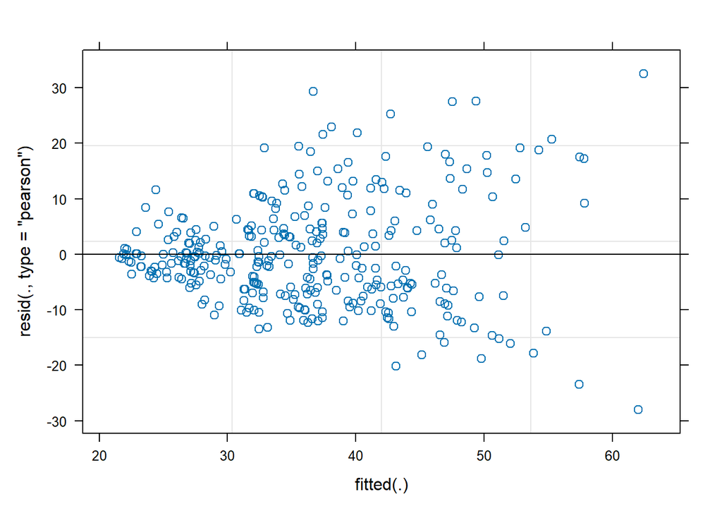

```r
plot(mod1)
```

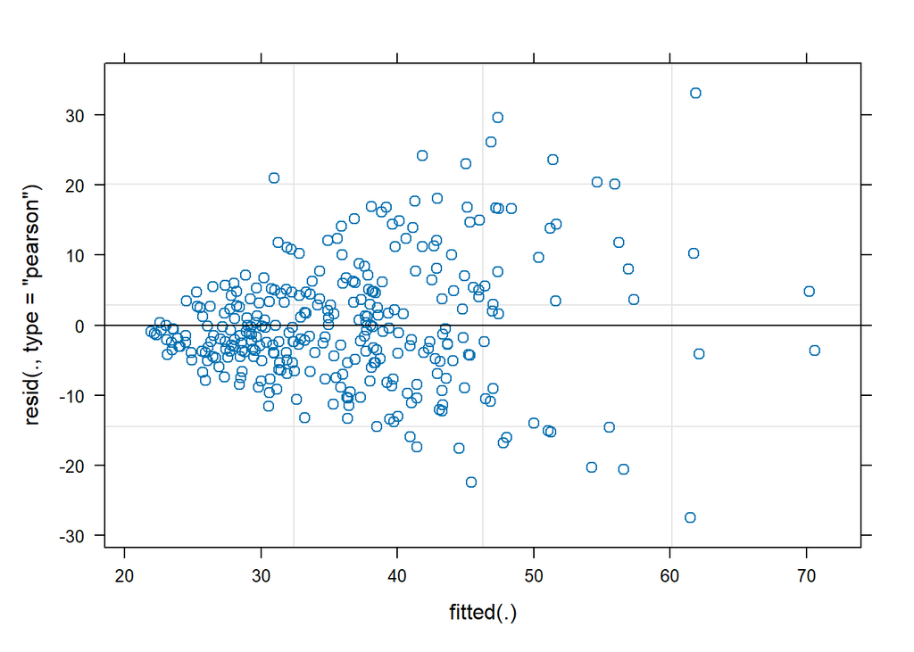

```r
plot(mod2)
```

The residual plots don’t look very good. In fact there is definitely a conical/fan shape ~ this suggests residuals aren’t randomly distributed or they point to something non-random in the unexplained variance.

```r
mod3 <- lmer(values ~ treatment*weeks + (1 | subject), data = bprslong1, REML = FALSE)
summary(mod3)
```

```
## Linear mixed model fit by maximum likelihood  ['lmerMod']
## Formula: values ~ treatment * weeks + (1 | subject)
##    Data: bprslong1
##
##      AIC      BIC   logLik deviance df.resid
##   2430.7   2498.5  -1197.3   2394.7      302
##
## Scaled residuals:
##     Min      1Q  Median      3Q     Max
## -3.0278 -0.6690 -0.0629  0.4330  3.4941
##
## Random effects:
##  Groups   Name        Variance Std.Dev.
##  subject  (Intercept) 50.03    7.073
##  Residual             90.23    9.499
## Number of obs: 320, groups:  subject, 20
##
## Fixed effects:
##                   Estimate Std. Error t value
## (Intercept)         46.800      2.648  17.672
## treatment2          -0.950      3.004  -0.316
## weeks2              -3.250      3.004  -1.082
## weeks3              -5.900      3.004  -1.964
## weeks4             -10.200      3.004  -3.396
## weeks5             -14.100      3.004  -4.694
## weeks6             -17.100      3.004  -5.693
## weeks7             -17.000      3.004  -5.660
## weeks8             -17.500      3.004  -5.826
## treatment2:weeks2   -2.750      4.248  -0.647
## treatment2:weeks3   -2.550      4.248  -0.600
## treatment2:weeks4    0.450      4.248   0.106
## treatment2:weeks5    0.650      4.248   0.153
## treatment2:weeks6    4.000      4.248   0.942
## treatment2:weeks7    5.750      4.248   1.354
## treatment2:weeks8    5.200      4.248   1.224
```

```
##
## Correlation matrix not shown by default, as p = 16 > 12.
## Use print(x, correlation=TRUE)  or
##     vcov(x)        if you need it
```

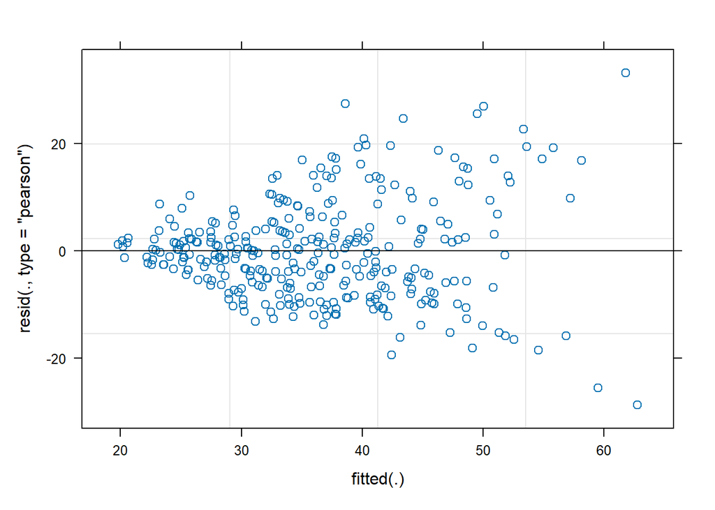

```r
plot(mod3)
```

this still looks bad…lets see what the fitted values look like compared to the observed.

```r
Fitted1<-fitted(mod1)
Fitted2 <- fitted(mod2)
Fitted3<-fitted(mod3)
bprslong_fitted<- cbind(Fitted1,Fitted2,Fitted3,bprslong1)
bprslong_fitted$values<-as.numeric(bprslong_fitted$values)

str(bprslong_fitted)
```

```
## 'data.frame':    320 obs. of  7 variables:
##  $ Fitted1  : num  53.9 42.7 42 49.4 57.4 ...
##  $ Fitted2  : num  46.5 45 38.8 47.4 70.2 ...
##  $ Fitted3  : num  54.6 43.4 42.7 50.1 58.2 ...
##  $ treatment: Factor w/ 2 levels "1","2": 1 1 1 1 1 1 1 1 1 1 ...
##  $ subject  : Factor w/ 20 levels "1","2","3","4",..: 1 2 3 4 5 6 7 8 9 10 ...
##  $ weeks    : Factor w/ 9 levels "0","1","2","3",..: 2 2 2 2 2 2 2 2 2 2 ...
##  $ values   : num  36 68 55 77 75 43 61 36 43 51 ...
```

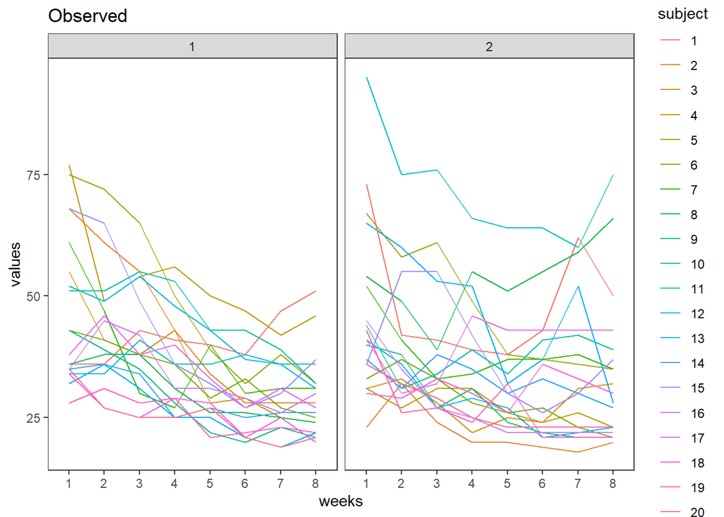

```r
gg6 <- ggplot(bprslong_fitted, aes( x= weeks, y = values, group=subject,colour=subject))+
  geom_line()+ theme_bw() + theme(legend.position = "right")+ theme(panel.grid.major = element_blank(), panel.grid.minor = element_blank()) + facet_wrap(.~treatment)+ggtitle("Observed")
gg6
```

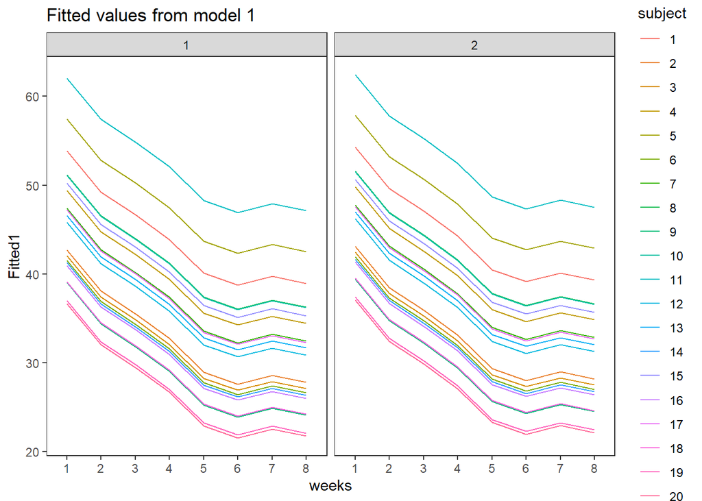

```r
gg7<- ggplot(bprslong_fitted, aes( x= weeks, y = Fitted1, group = subject,colour=subject))+ geom_line()+ theme_bw() + theme(legend.position = "right")+ theme(panel.grid.major = element_blank(), panel.grid.minor = element_blank()) + facet_wrap(.~treatment)+ggtitle("Fitted values from model 1")
gg7
```

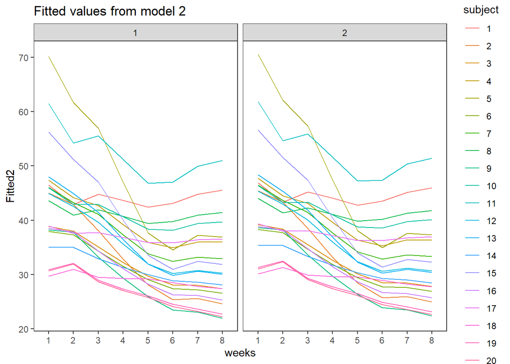

```r
gg8 <- ggplot(bprslong_fitted, aes( x= weeks, y = Fitted2, group = subject,colour=subject))+ geom_line()+ theme_bw() + theme(legend.position = "right")+ theme(panel.grid.major = element_blank(), panel.grid.minor = element_blank()) + facet_wrap(.~treatment)+ggtitle("Fitted values from model 2")
gg8
```

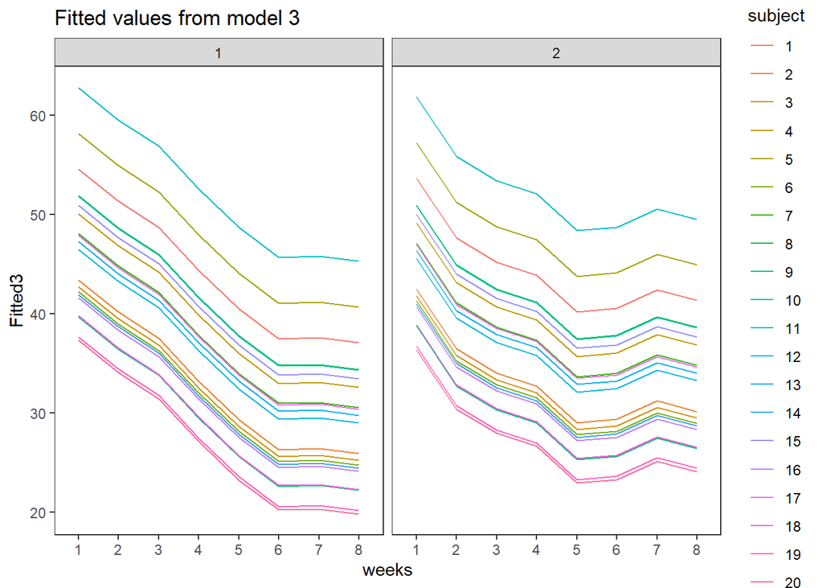

```r
gg9<- ggplot(bprslong_fitted, aes( x= weeks, y = Fitted3, group=subject,colour=subject))+
  geom_line()+ theme_bw() + theme(legend.position = "right")+ theme(panel.grid.major = element_blank(), panel.grid.minor = element_blank()) + facet_wrap(.~treatment)+ggtitle("Fitted values from model 3")
gg9
```

```r
anova(mod1,mod2,mod3)
```

```
## Data: bprslong1
## Models:
## mod1: values ~ treatment + weeks + (1 | subject)
## mod3: values ~ treatment * weeks + (1 | subject)
## mod2: values ~ treatment + (weeks | subject)
##      npar    AIC    BIC  logLik deviance  Chisq Df Pr(>Chisq)
## mod1   11 2425.0 2466.4 -1201.5   2403.0
## mod3   18 2430.7 2498.5 -1197.3   2394.7 8.3447  7     0.3032
## mod2   39 2496.5 2643.4 -1209.2   2418.5 0.0000 21     1.0000
```

The observed and fitted values for patients look a bit different, because the fitted values are a result of linear models that suggest distress score (values) generally go down as weeks progress. This is not a terrible assumption, but we can see that there are definitely some patients whose distress score that go up from the raw data.

Model 3 assumes that there is some kind of interaction between time and treatment as a linear effect. According to the negative values on the intercept for weeks, over time the distress level generally goes down (much stronger trend than suggested in mod2). According to the anova, mod1 is still the best on AIC, but mod 3 is not far behind.

The individuals’ responses don’t overlap in model 1 and 3. This is because model is assuming complete independence.